# 3 Primary Endpoint Analysis

Adapted to illustrate agentic code review with Claude Code

Author

Example Author

Published

August 10, 2026

## 3.1 Background

> **Important:** This is a **mock study** created exclusively to illustrate the capabilities of [Claude Code](https://claude.ai/code) for agentic code review and validation. Drug names have been replaced with placeholders (**Drug A**, **Drug B**). All data are fully simulated. No real-world clinical conclusions should be drawn from this analysis.

This document implements a **primary endpoint analysis** following the general design of a target trial emulation comparing new users of **Drug A** versus **Drug B** in a chronic disease setting. It uses entirely synthetic data and generic drug labels.

The **primary outcome** is a composite of **hospitalization for heart failure (HF) or all-cause mortality**, assessed over up to 52 weeks of follow-up. Because treatment is not randomized, initiators of the two drugs differ at baseline (*confounding by indication*). We address this with **propensity-score overlap (ATO) weighting**, then estimate the treatment effect with a weighted Cox proportional-hazards model.

```r
# Generate the simulated cohort in memory by sourcing the data-generation
# function (nothing is read from / written to disk). Resolve the script path
# whether rendered from the project root or from inside mock-study/.
gen_script <- c("02_data_generation.R", file.path("mock-study", "02_data_generation.R"))
source(gen_script[file.exists(gen_script)][1])
cohort <- generate_cohort()

# Confounders to adjust for (baseline covariates).
covariates <- c(
  "age", "female", "race", "region",
  "bmi", "prior_hf_hosp", "diuretic_use",
  "nephropathy", "neuropathy", "retinopathy", "foot_ulcer", "insulin_use",
  "pad", "afib", "cardiomyopathy", "ckd",
  "copd", "depression", "dementia",
  "metformin", "sulfonylurea", "sglt2i", "statin", "anticoagulant",
  "n_hospitalizations", "n_ed_visits", "n_distinct_meds", "comorbidity_index"
)

# Human-readable variable labels (used by gtsummary tables).
var_labels <- list(
  age = "Age, years", female = "Female sex", race = "Race", region = "Region",
  bmi = "Body mass index, kg/m²", prior_hf_hosp = "Prior HF hospitalization",
  diuretic_use = "Diuretic use", nephropathy = "Diabetic nephropathy",
  neuropathy = "Diabetic neuropathy", retinopathy = "Diabetic retinopathy",
  foot_ulcer = "Foot ulcer", insulin_use = "Insulin use",
  pad = "Peripheral arterial disease", afib = "Atrial fibrillation",
  cardiomyopathy = "Cardiomyopathy", ckd = "Chronic kidney disease",
  copd = "COPD", depression = "Depression", dementia = "Dementia",
  metformin = "Metformin", sulfonylurea = "Sulfonylurea", sglt2i = "SGLT2 inhibitor",
  statin = "Statin", anticoagulant = "Anticoagulant",
  n_hospitalizations = "No. hospitalizations (prior yr)",
  n_ed_visits = "No. ED visits (prior yr)",
  n_distinct_meds = "No. distinct medications",
  comorbidity_index = "Combined comorbidity index"
)
```

The analytic cohort comprises **28,100** patients (11,864 Drug A, 16,236 Drug B).

## 3.2 Step 1 — Baseline characteristics (before weighting)

Several covariates show meaningful imbalance (|SMD| > 0.1), confirming confounding by indication: Drug A initiators are younger, have higher BMI, and carry a lower cardiovascular/comorbidity burden.

## 3.3 Step 2 — Propensity score estimation and overlap (ATO) weighting

We estimate the propensity score (probability of receiving Drug A) with a logistic regression on all baseline covariates, then derive **overlap (ATO) weights**. Overlap weights emphasize patients with propensity scores in the region of clinical equipoise and yield exact mean balance on every covariate included in the model.

```r
ps_formula <- reformulate(covariates, response = "treatment")

W <- weightit(
  ps_formula,
  data      = cohort,
  method    = "glm",     # logistic-regression propensity score
  estimand  = "ATO"      # average treatment effect in the overlap population
)

cohort$ato_weight <- W$weights
W
```

```
A weightit object
 - method: "glm" (propensity score weighting with GLM)
 - number of obs.: 28100
 - sampling weights: none
 - treatment: 2-category
 - estimand: ATO
 - covariates: age, female, race, region, bmi, prior_hf_hosp, diuretic_use, nephropathy, neuropathy, retinopathy, foot_ulcer, insulin_use, pad, afib, cardiomyopathy, ckd, copd, depression, dementia, metformin, sulfonylurea, sglt2i, statin, anticoagulant, n_hospitalizations, n_ed_visits, n_distinct_m…
```

### 3.3.1 Covariate balance before vs. after weighting

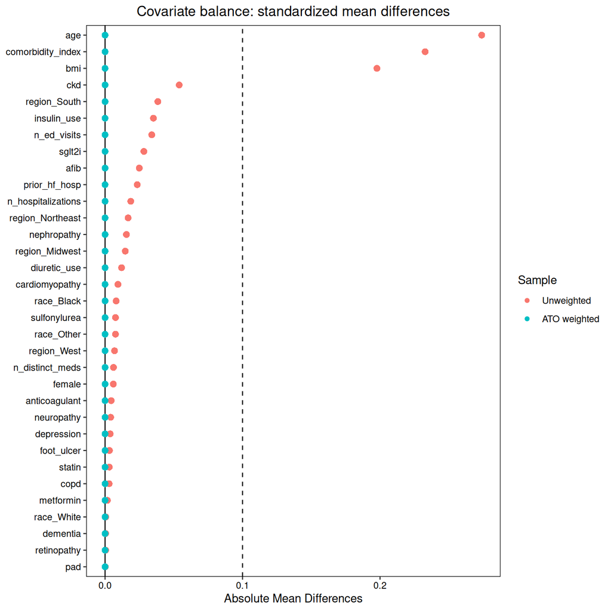

```r
love.plot(
  W,
  stats        = "mean.diffs",
  abs          = TRUE,
  thresholds   = c(m = 0.1),
  var.order    = "unadjusted",
  drop.distance = TRUE,
  sample.names = c("Unweighted", "ATO weighted"),
  title        = "Covariate balance: standardized mean differences"
)
```

After overlap weighting, all standardized mean differences are driven to ~0, indicating excellent balance.

### 3.3.2 Propensity score overlap

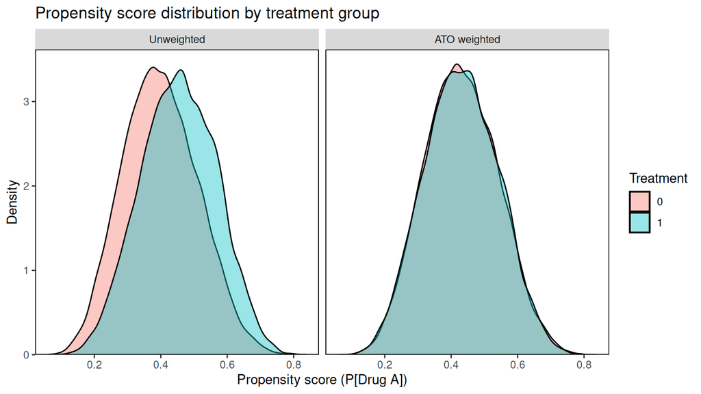

```r
bal.plot(
  W,
  var.name = "prop.score",
  which    = "both",
  type     = "density",
  sample.names = c("Unweighted", "ATO weighted")
) +
  labs(title = "Propensity score distribution by treatment group",
       x = "Propensity score (P[Drug A])")
```

### 3.3.3 Baseline characteristics — before and after ATO weighting

```r
tbl_merge(
  tbls        = list(tbl_unwt, tbl_wt),
  tab_spanner = c("**Unweighted**", "**ATO weighted**")
) |>
  modify_caption(
    "**Table 1. Baseline characteristics before and after ATO overlap weighting**"
  )
```

**Table 1. Baseline characteristics before and after ATO overlap weighting**

| **Characteristic** | **Unweighted** **Drug B** N = 16,236<sup>1</sup> | **Unweighted** **Drug A** N = 11,864<sup>1</sup> | **Unweighted** **SMD** | **Unweighted** **p-value** | **ATO weighted** **Drug B** N = 6,479<sup>1</sup> | **ATO weighted** **Drug A** N = 6,479<sup>1</sup> | **ATO weighted** **SMD** | **ATO weighted** **p-value** |
| --- | --- | --- | --- | --- | --- | --- | --- | --- |
| Age, years | 66.2 (9.9) | 63.5 (9.8) |  |  | 64.6 (9.9) | 64.6 (9.8) |  |  |
| Female sex | 7,934 (49%) | 5,726 (48%) |  |  | 3,146 (49%) | 3,146 (49%) |  |  |
| Race |  |  |  |  |  |  |  |  |
| Black | 2,920 (18%) | 2,038 (17%) |  |  | 1,138 (18%) | 1,138 (18%) |  |  |
| Other | 1,897 (12%) | 1,476 (12%) |  |  | 788 (12%) | 788 (12%) |  |  |
| White | 11,419 (70%) | 8,350 (70%) |  |  | 4,553 (70%) | 4,553 (70%) |  |  |
| Region |  |  |  |  |  |  |  |  |
| Midwest | 3,619 (22%) | 2,819 (24%) |  |  | 1,496 (23%) | 1,496 (23%) |  |  |
| Northeast | 3,082 (19%) | 2,451 (21%) |  |  | 1,297 (20%) | 1,297 (20%) |  |  |
| South | 6,405 (39%) | 4,225 (36%) |  |  | 2,417 (37%) | 2,417 (37%) |  |  |
| West | 3,130 (19%) | 2,369 (20%) |  |  | 1,270 (20%) | 1,270 (20%) |  |  |
| Body mass index, kg/m² | 32.6 (5.0) | 33.6 (5.0) |  |  | 33.2 (5.0) | 33.2 (5.0) |  |  |
| Prior HF hospitalization | 1,145 (7.1%) | 559 (4.7%) |  |  | 358 (5.5%) | 358 (5.5%) |  |  |
| Diuretic use | 4,613 (28%) | 3,228 (27%) |  |  | 1,797 (28%) | 1,797 (28%) |  |  |
| Diabetic nephropathy | 2,533 (16%) | 1,667 (14%) |  |  | 947 (15%) | 947 (15%) |  |  |
| Diabetic neuropathy | 3,544 (22%) | 2,638 (22%) |  |  | 1,431 (22%) | 1,431 (22%) |  |  |
| Diabetic retinopathy | 2,006 (12%) | 1,461 (12%) |  |  | 798 (12%) | 798 (12%) |  |  |
| Foot ulcer | 773 (4.8%) | 603 (5.1%) |  |  | 317 (4.9%) | 317 (4.9%) |  |  |
| Insulin use | 5,134 (32%) | 3,334 (28%) |  |  | 1,917 (30%) | 1,917 (30%) |  |  |
| Peripheral arterial disease | 1,631 (10%) | 1,194 (10%) |  |  | 650 (10%) | 650 (10%) |  |  |
| Atrial fibrillation | 2,127 (13%) | 1,259 (11%) |  |  | 749 (12%) | 749 (12%) |  |  |
| Cardiomyopathy | 1,191 (7.3%) | 759 (6.4%) |  |  | 438 (6.8%) | 438 (6.8%) |  |  |
| Chronic kidney disease | 3,603 (22%) | 1,993 (17%) |  |  | 1,224 (19%) | 1,224 (19%) |  |  |
| COPD | 2,117 (13%) | 1,512 (13%) |  |  | 836 (13%) | 836 (13%) |  |  |
| Depression | 2,868 (18%) | 2,140 (18%) |  |  | 1,156 (18%) | 1,156 (18%) |  |  |
| Dementia | 653 (4.0%) | 482 (4.1%) |  |  | 264 (4.1%) | 264 (4.1%) |  |  |
| Metformin | 11,689 (72%) | 8,521 (72%) |  |  | 4,653 (72%) | 4,653 (72%) |  |  |
| Sulfonylurea | 5,698 (35%) | 4,254 (36%) |  |  | 2,313 (36%) | 2,313 (36%) |  |  |
| SGLT2 inhibitor | 4,672 (29%) | 3,749 (32%) |  |  | 1,963 (30%) | 1,963 (30%) |  |  |
| Statin | 10,522 (65%) | 7,725 (65%) |  |  | 4,208 (65%) | 4,208 (65%) |  |  |
| Anticoagulant | 2,299 (14%) | 1,733 (15%) |  |  | 932 (14%) | 932 (14%) |  |  |
| No. hospitalizations (prior yr) |  |  |  |  |  |  |  |  |
| 0 | 10,933 (67%) | 7,846 (66%) |  |  | 4,331 (67%) | 4,306 (66%) |  |  |
| 1 | 4,274 (26%) | 3,268 (28%) |  |  | 1,723 (27%) | 1,768 (27%) |  |  |
| 2 | 893 (5.5%) | 650 (5.5%) |  |  | 368 (5.7%) | 352 (5.4%) |  |  |
| 3 | 125 (0.8%) | 93 (0.8%) |  |  | 53 (0.8%) | 49 (0.8%) |  |  |
| 4 | 10 (<0.1%) | 5 (<0.1%) |  |  | 4 (<0.1%) | 3 (<0.1%) |  |  |
| 5 | 1 (<0.1%) | 2 (<0.1%) |  |  | 0 (<0.1%) | 1 (<0.1%) |  |  |
| No. ED visits (prior yr) |  |  |  |  |  |  |  |  |
| 0 | 9,026 (56%) | 6,374 (54%) |  |  | 3,562 (55%) | 3,525 (54%) |  |  |
| 1 | 5,211 (32%) | 3,938 (33%) |  |  | 2,084 (32%) | 2,135 (33%) |  |  |
| 2 | 1,605 (9.9%) | 1,257 (11%) |  |  | 661 (10%) | 667 (10%) |  |  |
| 3 | 338 (2.1%) | 255 (2.1%) |  |  | 147 (2.3%) | 133 (2.1%) |  |  |
| 4 | 50 (0.3%) | 39 (0.3%) |  |  | 22 (0.3%) | 20 (0.3%) |  |  |
| 5 | 6 (<0.1%) | 0 (0%) |  |  | 2 (<0.1%) | 0 (0%) |  |  |
| 6 | 0 (0%) | 1 (<0.1%) |  |  | 0 (0%) | 0 (<0.1%) |  |  |
| No. distinct medications | 8.0 (2.8) | 8.0 (2.8) |  |  | 8.0 (2.8) | 8.0 (2.8) |  |  |
| Combined comorbidity index | 2.2 (1.4) | 1.9 (1.3) |  |  | 2.0 (1.4) | 2.0 (1.4) |  |  |

<sup>1</sup> Mean (SD); n (%)  
Abbreviation: CI = Confidence Interval

## 3.4 Step 3 — Primary endpoint analysis (weighted Cox model)

The treatment effect on the composite endpoint is estimated with a Cox proportional-hazards model incorporating the overlap weights. Robust (sandwich) standard errors account for the weighting.

```r
cox_wt <- coxph(
  Surv(time, status) ~ treatment_label,
  data    = cohort,
  weights = cohort$ato_weight,
  robust  = TRUE
)

tbl_regression(cox_wt, exponentiate = TRUE) |>
  modify_header(estimate ~ "**HR**") |>
  modify_caption(
    "**Table 2. Primary composite endpoint — ATO-weighted hazard ratio**"
  )
```

**Table 2. Primary composite endpoint — ATO-weighted hazard ratio**

| **Characteristic** | **HR** | **95% CI** | **p-value** |
| --- | --- | --- | --- |
| treatment_label |  |  |  |
| Drug B | — | — |  |
| Drug A | 0.86 | 0.73, 1.02 | 0.091 |

Abbreviations: CI = Confidence Interval, HR = Hazard Ratio

```r
hr      <- exp(coef(cox_wt))[["treatment_labelDrug A"]]
ci      <- exp(confint(cox_wt))["treatment_labelDrug A", ]
hr_text <- sprintf("%.2f (95%% CI, %.2f-%.2f)", hr, ci[1], ci[2])
```

**Primary result:** Drug A vs. Drug B HR = **0.86 (95% CI, 0.73-1.02)** for the composite of HF hospitalization or all-cause mortality.

## 3.5 Step 4 — One-year cumulative incidence

```r
fit_wt <- survfit(
  Surv(time, status) ~ treatment_label,
  data    = cohort,
  weights = cohort$ato_weight
)

risk_1yr <- summary(fit_wt, times = 365)
risk_tbl <- data.frame(
  Group         = sub("treatment_label=", "", risk_1yr$strata),
  `1-year risk` = sprintf("%.1f%% (95%% CI, %.1f%%-%.1f%%)",
                          100 * (1 - risk_1yr$surv),
                          100 * (1 - risk_1yr$lower),
                          100 * (1 - risk_1yr$upper)),
  check.names = FALSE
)
kable(risk_tbl, caption = "Table 3. ATO-weighted 1-year risk by arm")
```

Table 3. ATO-weighted 1-year risk by arm

| Group | 1-year risk |
| --- | --- |
| Drug B | 3.4% (95% CI, 3.7%-3.1%) |
| Drug A | 3.0% (95% CI, 3.4%-2.6%) |

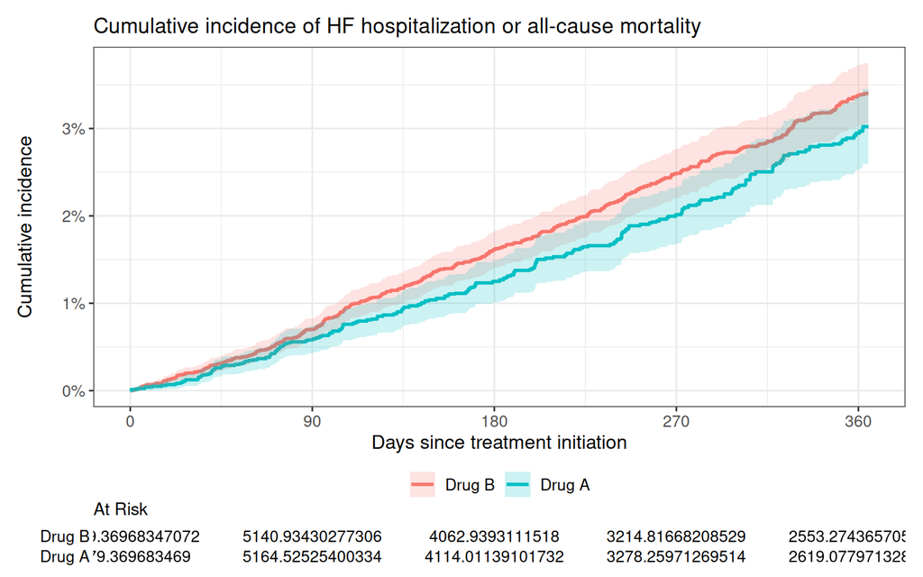

```r
survfit2(
  Surv(time, status) ~ treatment_label,
  data    = cohort,
  weights = cohort$ato_weight
) |>
  ggsurvfit(type = "risk", linewidth = 1) +
  add_confidence_interval() +
  add_risktable(risktable_stats = "n.risk") +
  coord_cartesian(xlim = c(0, 365)) +
  scale_x_continuous(breaks = seq(0, 365, 90)) +
  scale_y_continuous(labels = percent) +
  labs(
    title = "Cumulative incidence of HF hospitalization or all-cause mortality",
    x = "Days since treatment initiation",
    y = "Cumulative incidence"
  )
```